# Mahsa Massoud

## 810198032

## AI- project5 -Phase2

```python
from google.colab import drive
drive.mount('/content/drive')
```

```python
!cp "/content/drive/MyDrive/UTKFace.tar.gz" .
```

```python
!tar xvzf UTKFace.tar.gz
```

[output not shown]

[output cut: 4946 more lines]

[output not shown]

```python
from tensorflow.keras import *
from tensorflow.keras.utils import *
import numpy as np
import pandas as pd
import matplotlib.pyplot as plt
import os
from sklearn.metrics import classification_report
import tensorboard
```

```python
img_path = []
races = []
path = "/content/UTKFace"
for img in os.listdir(path):
  temp = img.split('.')
  if len(temp[0].split('_')) == 4:
    img_path.append(os.path.join(path, img))
    age, gender, race, date = temp[0].split('_')
    races.append(race)
```

```python
class_labels = { 0:"White" , 1 : "Black" , 2:"Asian" ,
                3:"Indian" , 4:"Others"}

races = [str(to_categorical(i,len(class_labels))) for i in races]

df = pd.DataFrame({'image' : img_path , 'Race': races})
```

One hot encoding is done inorder to eliminate the effect of numbers and their meanings for model, because they are just labels and the absolute value and difference between them is meaningless and this subject should induce to model by one hot encoding.

```python
df
```

|  | image | Race |
| --- | --- | --- |
| 0 | /content/UTKFace/25_1_1_20170117142659506.jpg.... | [0. 1. 0. 0. 0.] |
| 1 | /content/UTKFace/7_0_3_20170119144311624.jpg.c... | [0. 0. 0. 1. 0.] |
| 2 | /content/UTKFace/1_1_3_20161220220119985.jpg.c... | [0. 0. 0. 1. 0.] |
| 3 | /content/UTKFace/70_0_0_20170117175207508.jpg.... | [1. 0. 0. 0. 0.] |
| 4 | /content/UTKFace/35_0_1_20170113155156475.jpg.... | [0. 1. 0. 0. 0.] |
| ... | ... | ... |
| 23700 | /content/UTKFace/35_0_1_20170113182403214.jpg.... | [0. 1. 0. 0. 0.] |
| 23701 | /content/UTKFace/28_0_1_20170113133624449.jpg.... | [0. 1. 0. 0. 0.] |
| 23702 | /content/UTKFace/58_1_1_20170112213645366.jpg.... | [0. 1. 0. 0. 0.] |
| 23703 | /content/UTKFace/30_0_1_20170117123820956.jpg.... | [0. 1. 0. 0. 0.] |
| 23704 | /content/UTKFace/34_1_0_20170117190413161.jpg.... | [1. 0. 0. 0. 0.] |

23705 rows × 2 columns

```python
dataGenerator = preprocessing.image.ImageDataGenerator(rescale=1.0/255, validation_split=0.25)
```

```python
X_train = dataGenerator.flow_from_dataframe(
    dataframe = df,
    x_col = "image",
    y_col = "Race",
    target_size = (100, 100),
    color_mode = "grayscale",
    batch_size = 32,
    subset = 'training',
    shuffle = False
)
```

```
Found 17779 validated image filenames belonging to 5 classes.
```

```python
X_test = dataGenerator.flow_from_dataframe(
    dataframe = df,
    x_col = "image",
    y_col = "Race",
    target_size = (100, 100),
    color_mode = "grayscale",
    batch_size = 32,
    subset = 'validation',
    shuffle = False
)
```

```
Found 5926 validated image filenames belonging to 5 classes.
```

```python
type(df.index)
```

```
pandas.core.indexes.range.RangeIndex
```

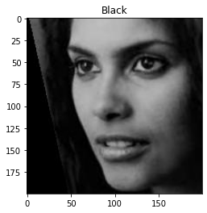

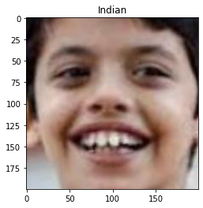

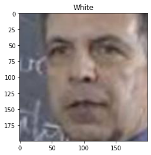

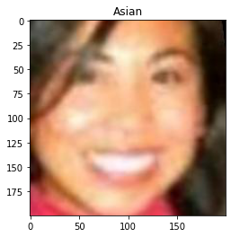

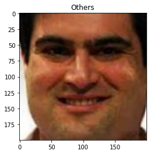

```
<BarContainer object of 5 artists>
```

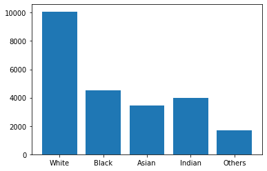

```python
import cv2

counters = [0,0,0,0,0]
Printeds = [0,0,0,0,0]
for i in df.index:
  race_list = df['Race'][i]
  label_index = race_list.index(1)
  counters[label_index] += 1
  if( Printeds[label_index] == 0):
    plt.figure()
    img = cv2.cvtColor(cv2.imread(df['image'][i]) ,cv2.COLOR_BGR2RGB)
    plt.imshow(img)
    plt.title(class_labels[label_index])
    plt.show()
    Printeds[label_index] = 1
plt.bar(class_labels.values, counters)
```

```python
from keras.layers import Dense, Activation, Flatten
inp = layers.Input(shape = (100, 100, 1))

output = layers.Flatten()(inp)
output = layers.Dense(1024, activation="relu")(output)
output = layers.Dense(512, activation="relu")(output)
output = layers.Dense(5, activation="softmax")(output)

model = models.Model(inputs = inp, outputs = output)
```

```python
model.summary()
```

```
Model: "model"
_________________________________________________________________
Layer (type)                 Output Shape              Param #
=================================================================
input_1 (InputLayer)         [(None, 100, 100, 1)]     0
_________________________________________________________________
flatten (Flatten)            (None, 10000)             0
_________________________________________________________________
dense (Dense)                (None, 1024)              10241024
_________________________________________________________________
dense_1 (Dense)              (None, 512)               524800
_________________________________________________________________
dense_2 (Dense)              (None, 5)                 2565
=================================================================
Total params: 10,768,389
Trainable params: 10,768,389
Non-trainable params: 0
_________________________________________________________________
```

```python
model.compile(optimizer=optimizers.SGD(learning_rate=0.01), loss="categorical_crossentropy", metrics=["accuracy"])
```

```python
history = model.fit(X_train, validation_data=X_test, epochs=10)
```

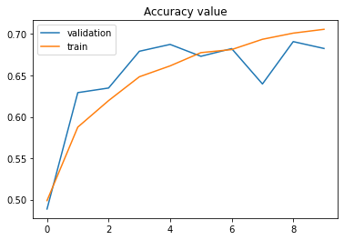

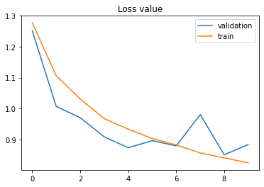

```python
plt.figure()
plt.title('Accuracy value')
plt.plot(np.arange(10), history.history["val_accuracy"], label='validation')
plt.plot(np.arange(10), history.history["accuracy"], label='train')
plt.legend()
plt.show()

plt.figure()
plt.title('Loss value')
plt.plot(np.arange(10), history.history["val_loss"], label="validation")
plt.plot(np.arange(10), history.history["loss"], label = "train")
plt.legend()
plt.show()
```

```python
y_true  = X_test.labels
y_pred = np.argmax(model.predict(X_test) , axis = 1)

print("Classification Report fot Testing data")
print()
print(classification_report(y_true, y_pred, target_names =[class_labels[i] for i in class_labels]))
```

```
Classification Report fot Testing data

              precision    recall  f1-score   support

       White       0.29      0.03      0.05       441
       Black       0.70      0.39      0.50       984
       Asian       0.66      0.73      0.69       873
      Indian       0.89      0.65      0.75      1124
      Others       0.64      0.91      0.75      2504

    accuracy                           0.68      5926
   macro avg       0.64      0.54      0.55      5926
weighted avg       0.67      0.68      0.65      5926
```

```python
y_true_train  = X_train.labels
y_pred_train = np.argmax(model.predict(X_train) , axis = 1)

print("Classification Report fot Training data")
print()
print(classification_report(y_true_train, y_pred_train, target_names =[class_labels[i] for i in class_labels]))
```

```
Classification Report fot Training data

              precision    recall  f1-score   support

       White       0.49      0.03      0.06      1251
       Black       0.75      0.46      0.57      2991
       Asian       0.70      0.74      0.72      2561
      Indian       0.91      0.66      0.76      3402
      Others       0.66      0.93      0.77      7574

    accuracy                           0.71     17779
   macro avg       0.70      0.56      0.58     17779
weighted avg       0.72      0.71      0.68     17779
```

## Phase 3

```python
def test_network(activation , momentum = 0):
  inp = layers.Input(shape = (100, 100, 1))

  output = layers.Flatten()(inp)
  output = layers.Dense(1024, activation=activation)(output)
  output = layers.Dense(512, activation=activation)(output)
  output = layers.Dense(5, activation="softmax")(output)

  model = models.Model(inputs = inp, outputs = output)
  model.compile(optimizer=optimizers.SGD(learning_rate=0.01,  momentum = momentum ), loss="categorical_crossentropy", metrics=["accuracy"])
  history = model.fit(X_train, validation_data=X_test, epochs=10)
  y_true  = X_test.labels
  y_pred = np.argmax(model.predict(X_test) , axis = 1)

  print("Classification Report fot Testing data for " , activation , " function :")
  print()
  print(classification_report(y_true, y_pred, target_names =[class_labels[i] for i in class_labels]))
  plt.figure()
  plt.title('Accuracy value')
  plt.plot(np.arange(10), history.history["val_accuracy"], label='validation')
  plt.plot(np.arange(10), history.history["accuracy"], label='train')
  plt.legend()
  plt.show()

  plt.figure()
  plt.title('Loss value')
  plt.plot(np.arange(10), history.history["val_loss"], label="validation")
  plt.plot(np.arange(10), history.history["loss"], label = "train")
  plt.legend()
  plt.show()
  y_true  = X_test.labels
  y_pred = np.argmax(model.predict(X_test) , axis = 1)

  print("Classification Report fot Testing data :")
  print()
  print(classification_report(y_true, y_pred, target_names =[class_labels[i] for i in class_labels]))
```

```
Classification Report fot Testing data for  tanh  function :

              precision    recall  f1-score   support

       White       0.50      0.00      0.00       424
       Black       0.30      0.93      0.45      1030
       Asian       0.80      0.47      0.59       840
      Indian       0.82      0.68      0.74      1135
      Others       0.86      0.45      0.59      2497

    accuracy                           0.55      5926
   macro avg       0.66      0.51      0.48      5926
weighted avg       0.72      0.55      0.55      5926
```

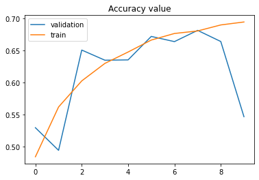

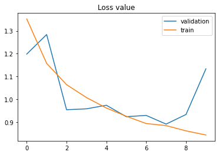

```
Classification Report fot Testing data

              precision    recall  f1-score   support

       White       0.50      0.00      0.00       424
       Black       0.30      0.93      0.45      1030
       Asian       0.80      0.47      0.59       840
      Indian       0.82      0.68      0.74      1135
      Others       0.86      0.45      0.59      2497

    accuracy                           0.55      5926
   macro avg       0.66      0.51      0.48      5926
weighted avg       0.72      0.55      0.55      5926
```

```python
test_network('tanh')
```

```python
test_network('sigmoid')
```

[output not shown]

```python
test_network('LeakyReLU')
```

```
Classification Report fot Testing data for  LeakyReLU  function :

              precision    recall  f1-score   support

       White       0.46      0.05      0.09       441
       Black       0.76      0.30      0.43       984
       Asian       0.63      0.76      0.69       873
      Indian       0.78      0.75      0.77      1124
      Others       0.66      0.89      0.76      2504

    accuracy                           0.68      5926
   macro avg       0.66      0.55      0.55      5926
weighted avg       0.68      0.68      0.65      5926
```

Momentum allows the optimizer to maintain the velocity and trajectory from previous time steps to affect the present.The momentum term increases for dimensions whose gradients point in the same directions and reduces updates for dimensions whose gradients change directions. As a result, we gain faster convergence and reduced oscillation. $ velocity = momentum * velocity - learningRate * g $

$ w = w + velocity $

```
Classification Report fot Testing data for  relu  function :

              precision    recall  f1-score   support

       White       0.26      0.08      0.12       424
       Black       0.64      0.56      0.60      1030
       Asian       0.85      0.36      0.51       840
      Indian       0.88      0.61      0.72      1135
      Others       0.61      0.92      0.73      2497

    accuracy                           0.66      5926
   macro avg       0.65      0.51      0.54      5926
weighted avg       0.68      0.66      0.63      5926
```

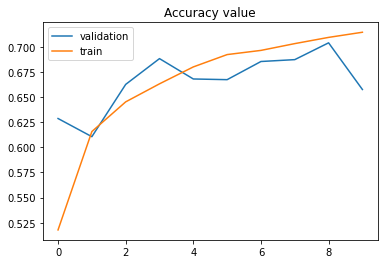

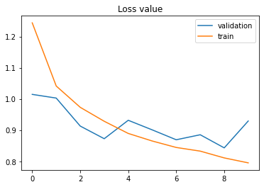

```
Classification Report fot Testing data

              precision    recall  f1-score   support

       White       0.26      0.08      0.12       424
       Black       0.64      0.56      0.60      1030
       Asian       0.85      0.36      0.51       840
      Indian       0.88      0.61      0.72      1135
      Others       0.61      0.92      0.73      2497

    accuracy                           0.66      5926
   macro avg       0.65      0.51      0.54      5926
weighted avg       0.68      0.66      0.63      5926
```

```python
# 1 : Optimizer
test_network('relu' , 0.5)
```

```
Classification Report fot Testing data for  relu  function :

              precision    recall  f1-score   support

       White       0.00      0.00      0.00       424
       Black       0.65      0.40      0.50      1030
       Asian       0.78      0.60      0.68       840
      Indian       0.66      0.81      0.73      1135
      Others       0.67      0.88      0.76      2497

    accuracy                           0.68      5926
   macro avg       0.55      0.54      0.53      5926
weighted avg       0.63      0.68      0.64      5926
```

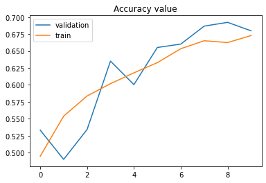

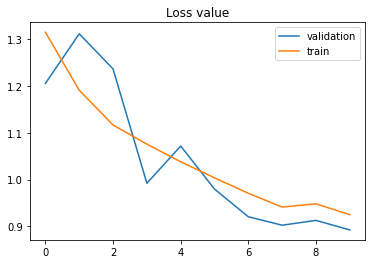

```
Classification Report fot Testing data :

              precision    recall  f1-score   support

       White       0.00      0.00      0.00       424
       Black       0.65      0.40      0.50      1030
       Asian       0.78      0.60      0.68       840
      Indian       0.66      0.81      0.73      1135
      Others       0.67      0.88      0.76      2497

    accuracy                           0.68      5926
   macro avg       0.55      0.54      0.53      5926
weighted avg       0.63      0.68      0.64      5926
```

```python
test_network('relu' , 0.9)
```

Adam

```
Classification Report fot Testing data for  relu  function :

              precision    recall  f1-score   support

       White       0.28      0.04      0.08       424
       Black       0.77      0.37      0.50      1030
       Asian       0.58      0.78      0.66       840
      Indian       0.69      0.82      0.75      1135
      Others       0.72      0.83      0.77      2497

    accuracy                           0.68      5926
   macro avg       0.61      0.57      0.55      5926
weighted avg       0.67      0.68      0.65      5926
```

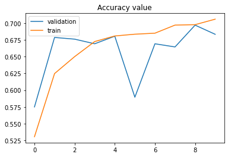

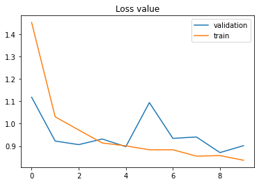

```
Classification Report fot Testing data

              precision    recall  f1-score   support

       White       0.28      0.04      0.08       424
       Black       0.77      0.37      0.50      1030
       Asian       0.58      0.78      0.66       840
      Indian       0.69      0.82      0.75      1135
      Others       0.72      0.83      0.77      2497

    accuracy                           0.68      5926
   macro avg       0.61      0.57      0.55      5926
weighted avg       0.67      0.68      0.65      5926
```

```python
inp = layers.Input(shape = (100, 100, 1))

output = layers.Flatten()(inp)
output = layers.Dense(1024, activation='relu')(output)
output = layers.Dense(512, activation='relu')(output)
output = layers.Dense(5, activation="softmax")(output)

model = models.Model(inputs = inp, outputs = output)
model.compile(optimizer=optimizers.Adam(), loss="categorical_crossentropy", metrics=["accuracy"])
history = model.fit(X_train, validation_data=X_test, epochs=10)
y_true  = X_test.labels
y_pred = np.argmax(model.predict(X_test) , axis = 1)

print("Classification Report fot Testing data for " , 'relu' , " function :")
print()
print(classification_report(y_true, y_pred, target_names =[class_labels[i] for i in class_labels]))
plt.figure()
plt.title('Accuracy value')
plt.plot(np.arange(10), history.history["val_accuracy"], label='validation')
plt.plot(np.arange(10), history.history["accuracy"], label='train')
plt.legend()
plt.show()

plt.figure()
plt.title('Loss value')
plt.plot(np.arange(10), history.history["val_loss"], label="validation")
plt.plot(np.arange(10), history.history["loss"], label = "train")
plt.legend()
plt.show()
y_true  = X_test.labels
y_pred = np.argmax(model.predict(X_test) , axis = 1)

print("Classification Report fot Testing data")
print()
print(classification_report(y_true, y_pred, target_names =[class_labels[i] for i in class_labels]))
```

## Epoch

```
Classification Report fot Testing data for  relu  function :

              precision    recall  f1-score   support

       White       0.28      0.11      0.16       424
       Black       0.63      0.65      0.64      1030
       Asian       0.72      0.73      0.73       840
      Indian       0.75      0.79      0.77      1135
      Others       0.77      0.81      0.79      2497

    accuracy                           0.72      5926
   macro avg       0.63      0.62      0.62      5926
weighted avg       0.70      0.72      0.70      5926
```

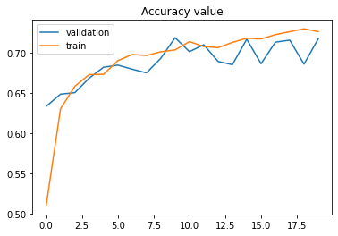

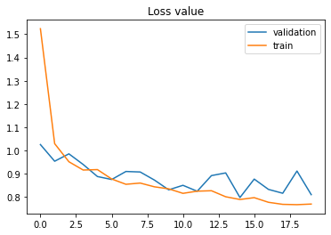

```
Classification Report fot Testing data

              precision    recall  f1-score   support

       White       0.28      0.11      0.16       424
       Black       0.63      0.65      0.64      1030
       Asian       0.72      0.73      0.73       840
      Indian       0.75      0.79      0.77      1135
      Others       0.77      0.81      0.79      2497

    accuracy                           0.72      5926
   macro avg       0.63      0.62      0.62      5926
weighted avg       0.70      0.72      0.70      5926
```

```python
#20
inp = layers.Input(shape = (100, 100, 1))

output = layers.Flatten()(inp)
output = layers.Dense(1024, activation='relu')(output)
output = layers.Dense(512, activation='relu')(output)
output = layers.Dense(5, activation="softmax")(output)

model = models.Model(inputs = inp, outputs = output)
model.compile(optimizer=optimizers.Adam(), loss="categorical_crossentropy", metrics=["accuracy"])
history = model.fit(X_train, validation_data=X_test, epochs=20)
y_true  = X_test.labels
y_pred = np.argmax(model.predict(X_test) , axis = 1)

print("Classification Report fot Testing data for " , 'relu' , " function :")
print()
print(classification_report(y_true, y_pred, target_names =[class_labels[i] for i in class_labels]))
plt.figure()
plt.title('Accuracy value')
plt.plot(np.arange(20), history.history["val_accuracy"], label='validation')
plt.plot(np.arange(20), history.history["accuracy"], label='train')
plt.legend()
plt.show()

plt.figure()
plt.title('Loss value')
plt.plot(np.arange(20), history.history["val_loss"], label="validation")
plt.plot(np.arange(20), history.history["loss"], label = "train")
plt.legend()
plt.show()
y_true  = X_test.labels
y_pred = np.argmax(model.predict(X_test) , axis = 1)

print("Classification Report fot Testing data")
print()
print(classification_report(y_true, y_pred, target_names =[class_labels[i] for i in class_labels]))
```

Clearly the accuracy increased in 20 epochs. The model should have a good performance on new unseen data and inorder to achieve this goal , the decreasing gradient should find the best possible weights and bias.So we need multiple of iteration to have the impact of all parameters and neurons to find extermum point correctly. This will be done until we find the point, in which the model starts overfittung. Some soulutions to prevent this are stopping training on the exact point of ovwrfitting, using regularization and dropouts.

## MSE

```
Classification Report fot Testing data for  relu  function :

              precision    recall  f1-score   support

       White       0.00      0.00      0.00       424
       Black       0.00      0.00      0.00      1030
       Asian       0.00      0.00      0.00       840
      Indian       0.00      0.00      0.00      1135
      Others       0.42      1.00      0.59      2497

    accuracy                           0.42      5926
   macro avg       0.08      0.20      0.12      5926
weighted avg       0.18      0.42      0.25      5926
```

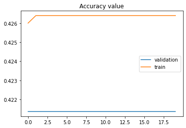

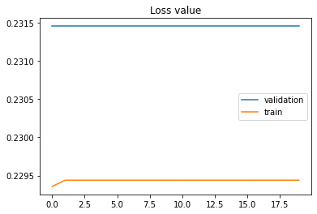

```
Classification Report fot Testing data

              precision    recall  f1-score   support

       White       0.00      0.00      0.00       424
       Black       0.00      0.00      0.00      1030
       Asian       0.00      0.00      0.00       840
      Indian       0.00      0.00      0.00      1135
      Others       0.42      1.00      0.59      2497

    accuracy                           0.42      5926
   macro avg       0.08      0.20      0.12      5926
weighted avg       0.18      0.42      0.25      5926
```

```python
inp = layers.Input(shape = (100, 100, 1))

output = layers.Flatten()(inp)
output = layers.Dense(1024, activation='relu')(output)
output = layers.Dense(512, activation='relu')(output)
output = layers.Dense(5, activation="softmax")(output)

model = models.Model(inputs = inp, outputs = output)
model.compile(optimizer=optimizers.Adam(), loss="mean_squared_error", metrics=["accuracy"])
history = model.fit(X_train, validation_data=X_test, epochs=20)
y_true  = X_test.labels
y_pred = np.argmax(model.predict(X_test) , axis = 1)

print("Classification Report fot Testing data for " , 'relu' , " function :")
print()
print(classification_report(y_true, y_pred, target_names =[class_labels[i] for i in class_labels]))
plt.figure()
plt.title('Accuracy value')
plt.plot(np.arange(20), history.history["val_accuracy"], label='validation')
plt.plot(np.arange(20), history.history["accuracy"], label='train')
plt.legend()
plt.show()

plt.figure()
plt.title('Loss value')
plt.plot(np.arange(20), history.history["val_loss"], label="validation")
plt.plot(np.arange(20), history.history["loss"], label = "train")
plt.legend()
plt.show()
y_true  = X_test.labels
y_pred = np.argmax(model.predict(X_test) , axis = 1)

print("Classification Report fot Testing data")
print()
print(classification_report(y_true, y_pred, target_names =[class_labels[i] for i in class_labels]))
```

As we see above the this classification model does not respond well to this loss function. This loss function is mostly used for regression and not for classification, because here the distance between outputs is high and convergance does not occur.

## Regularization:

Regularizers allow us to apply penalties on layer parameters or layer activity during optimization. These penalties are summed into the loss function that the network optimizes.These penalties affect most on unbalanced nodes and prevents overfitting.

```
Classification Report fot Testing data for  relu  function :

              precision    recall  f1-score   support

       White       0.00      0.00      0.00       424
       Black       0.50      0.65      0.57      1030
       Asian       0.84      0.50      0.63       840
      Indian       0.65      0.82      0.73      1135
      Others       0.73      0.78      0.75      2497

    accuracy                           0.67      5926
   macro avg       0.54      0.55      0.53      5926
weighted avg       0.64      0.67      0.64      5926
```

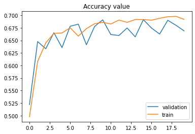

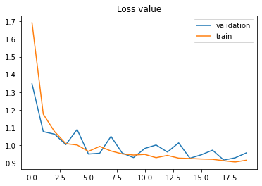

```
Classification Report fot Testing data

              precision    recall  f1-score   support

       White       0.00      0.00      0.00       424
       Black       0.50      0.65      0.57      1030
       Asian       0.84      0.50      0.63       840
      Indian       0.65      0.82      0.73      1135
      Others       0.73      0.78      0.75      2497

    accuracy                           0.67      5926
   macro avg       0.54      0.55      0.53      5926
weighted avg       0.64      0.67      0.64      5926
```

```python
#20
inp = layers.Input(shape = (100, 100, 1))

output = layers.Flatten()(inp)
output = layers.Dense(1024, activation='relu',    kernel_regularizer=regularizers.l2( l2=1e-4),
    bias_regularizer=regularizers.l2(1e-4),
    activity_regularizer=regularizers.l2(1e-4))(output)

output = layers.Dense(512, activation='relu',    kernel_regularizer=regularizers.l2( l2=1e-4),
    bias_regularizer=regularizers.l2(1e-4),
    activity_regularizer=regularizers.l2(1e-4))(output)

output = layers.Dense(5, activation="softmax")(output)

model = models.Model(inputs = inp, outputs = output)
model.compile(optimizer=optimizers.Adam(), loss="categorical_crossentropy", metrics=["accuracy"])

history = model.fit(X_train, validation_data=X_test, epochs=20)
y_true  = X_test.labels
y_pred = np.argmax(model.predict(X_test) , axis = 1)

print("Classification Report fot Testing data for " , 'relu' , " function :")
print()
print(classification_report(y_true, y_pred, target_names =[class_labels[i] for i in class_labels]))
plt.figure()
plt.title('Accuracy value')
plt.plot(np.arange(20), history.history["val_accuracy"], label='validation')
plt.plot(np.arange(20), history.history["accuracy"], label='train')
plt.legend()
plt.show()

plt.figure()
plt.title('Loss value')
plt.plot(np.arange(20), history.history["val_loss"], label="validation")
plt.plot(np.arange(20), history.history["loss"], label = "train")
plt.legend()
plt.show()
y_true  = X_test.labels
y_pred = np.argmax(model.predict(X_test) , axis = 1)

print("Classification Report fot Testing data")
print()
print(classification_report(y_true, y_pred, target_names =[class_labels[i] for i in class_labels]))
```

In this problem, the model is simple and using regularization and dropout is unnecessary and may even reduce the accuracy due to its underfitting effect.

## DropOut

Dropout ignores random neurons with the probability of 0.1(in this case) and it is one of the other metods of regularization to prevent overfitting.

```
Classification Report fot Testing data for  relu  function :

              precision    recall  f1-score   support

       White       0.00      0.00      0.00       424
       Black       0.74      0.36      0.49      1030
       Asian       0.71      0.43      0.54       840
      Indian       0.75      0.76      0.76      1135
      Others       0.61      0.92      0.73      2497

    accuracy                           0.65      5926
   macro avg       0.56      0.49      0.50      5926
weighted avg       0.63      0.65      0.61      5926
```

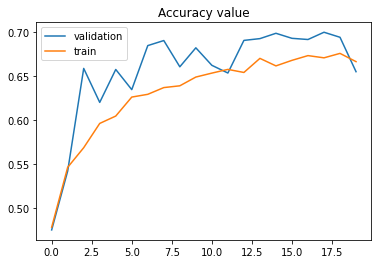

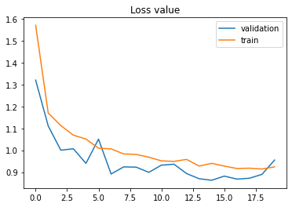

```
Classification Report fot Testing data

              precision    recall  f1-score   support

       White       0.00      0.00      0.00       424
       Black       0.74      0.36      0.49      1030
       Asian       0.71      0.43      0.54       840
      Indian       0.75      0.76      0.76      1135
      Others       0.61      0.92      0.73      2497

    accuracy                           0.65      5926
   macro avg       0.56      0.49      0.50      5926
weighted avg       0.63      0.65      0.61      5926
```

```python
#20
inp = layers.Input(shape = (100, 100, 1))

output = layers.Flatten()(inp)
output = layers.Dense(1024, activation='relu')(output)
output = layers.Dropout(0.1)(output)
output = layers.Dense(512, activation='relu')(output)
output = layers.Dropout(0.1)(output)
output = layers.Dense(5, activation="softmax")(output)

model = models.Model(inputs = inp, outputs = output)
model.compile(optimizer=optimizers.Adam(), loss="categorical_crossentropy", metrics=["accuracy"])
history = model.fit(X_train, validation_data=X_test, epochs=20)
y_true  = X_test.labels
y_pred = np.argmax(model.predict(X_test) , axis = 1)

print("Classification Report fot Testing data for " , 'relu' , " function :")
print()
print(classification_report(y_true, y_pred, target_names =[class_labels[i] for i in class_labels]))
plt.figure()
plt.title('Accuracy value')
plt.plot(np.arange(20), history.history["val_accuracy"], label='validation')
plt.plot(np.arange(20), history.history["accuracy"], label='train')
plt.legend()
plt.show()

plt.figure()
plt.title('Loss value')
plt.plot(np.arange(20), history.history["val_loss"], label="validation")
plt.plot(np.arange(20), history.history["loss"], label = "train")
plt.legend()
plt.show()
y_true  = X_test.labels
y_pred = np.argmax(model.predict(X_test) , axis = 1)

print("Classification Report fot Testing data")
print()
print(classification_report(y_true, y_pred, target_names =[class_labels[i] for i in class_labels]))
```